# An investigation of the long term ecological and soil carbon storage responses of the Upper Axe valley to landscape scale anthropogenic impacts

Julian Payne

2024

### MSc Land and Ecological Restoration - Research Project

# Variation of LOI with soil horizon and soil wetness

### Wetlands split into BuriedWetlands (including RiverBed) located underneath grey clays and Wetlands for contemporary overlying wetland soils and associated grey clay

```r
knitr::opts_chunk$set(message=FALSE,warning=FALSE)
```

## Load packages

```r
library(tidyverse)
library(here)
library(ggfortify)
library(readxl)
library(cowplot)
library(vegan)
library(lme4)
library(lmerTest)
```

## Load the data for the project

```r
filepath<-here("data","Soil_Cores.xlsx")
soil_cores<-read_excel(filepath,
                       sheet = "SoildataV3",
                       range = "A1:AB155")
```

## Set soil horizon layer order

```r
HorizonOrder<-c("Floodplain1", "Floodplain2", "Gley", "Wetland", "BuriedWetland")
WetnessOrder<-c("Dry", "Damp", "Wet")
```

### Clean up the data

Notice we have some missing values in the loi column, identified by 0 in test_for_loi

```r
soilloi_clean<-soil_cores %>%
  filter(horizon_type == "Floodplain2" | horizon_type == "Floodplain1" | horizon_type == "Gley" | horizon_type == "Wetland" | horizon_type == "BuriedWetland") %>%
  select(-loi) %>%
  drop_na()
```

## Consider variation with soil wetness

# Plot LOI against soil horizon for different soil wetnesses

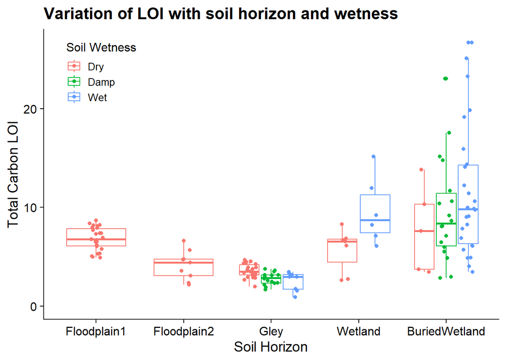

```r
soilloi_clean%>%
  ggplot(aes(x=reorder(horizon_type,Horizon_order), y=loi_calc, ymax =0.35, ymin = 0, colour = factor( wetdrydamp, ordered(WetnessOrder)))) +
  geom_boxplot()+
  geom_point(position = position_jitterdodge())+
    labs(x = "Soil Horizon",
       y = "Total Carbon LOI",
       title = "Variation of LOI with soil horizon and wetness",
       colour = "Soil Wetness") +
  theme_cowplot() +
  theme(legend.position = c(0.05,0.85), legend.title = element_text(size =12), legend.text = element_text(size=10))
```

# Test if soil horizon data sets are significantly different for soil wetness

# for gley soils

```r
GleyDryLoi<-soilloi_clean %>%
  filter(wetdrydamp=="Dry") %>%
  filter(horizon_type=="Gley") %>%
  select(loi_calc) %>%
  pull()

GleyDampLoi<-soilloi_clean %>%
  filter(wetdrydamp=="Damp") %>%
  filter(horizon_type=="Gley") %>%
  select(loi_calc) %>%
  pull()

GleyWetLoi<-soilloi_clean %>%
  filter(wetdrydamp=="Wet") %>%
  filter(horizon_type=="Gley") %>%
  select(loi_calc) %>%
  pull()

t.test(GleyDryLoi,GleyDampLoi)
```

```
##
##  Welch Two Sample t-test
##
## data:  GleyDryLoi and GleyDampLoi
## t = 3.7088, df = 34.792, p-value = 0.0007226
## alternative hypothesis: true difference in means is not equal to 0
## 95 percent confidence interval:
##  0.3579604 1.2241526
## sample estimates:
## mean of x mean of y
##  3.577227  2.786170
```

```r
t.test(GleyDryLoi,GleyWetLoi)
```

```
##
##  Welch Two Sample t-test
##
## data:  GleyDryLoi and GleyWetLoi
## t = 2.8374, df = 9.8573, p-value = 0.01787
## alternative hypothesis: true difference in means is not equal to 0
## 95 percent confidence interval:
##  0.2243236 1.8803207
## sample estimates:
## mean of x mean of y
##  3.577227  2.524905
```

```r
t.test(GleyDampLoi,GleyWetLoi)
```

```
##
##  Welch Two Sample t-test
##
## data:  GleyDampLoi and GleyWetLoi
## t = 0.70247, df = 9.9074, p-value = 0.4986
## alternative hypothesis: true difference in means is not equal to 0
## 95 percent confidence interval:
##  -0.5684838  1.0910151
## sample estimates:
## mean of x mean of y
##  2.786170  2.524905
```

# for Wetland soils

```r
WetDryLoi<-soilloi_clean %>%
  filter(wetdrydamp=="Dry") %>%
  filter(horizon_type=="Wetland") %>%
  select(loi_calc) %>%
  pull()

WetWetLoi<-soilloi_clean %>%
  filter(wetdrydamp=="Wet") %>%
  filter(horizon_type=="Wetland") %>%
  select(loi_calc) %>%
  pull()

t.test(WetDryLoi,WetWetLoi)
```

```
##
##  Welch Two Sample t-test
##
## data:  WetDryLoi and WetWetLoi
## t = -2.4472, df = 8.3142, p-value = 0.03902
## alternative hypothesis: true difference in means is not equal to 0
## 95 percent confidence interval:
##  -7.5959930 -0.2505313
## sample estimates:
## mean of x mean of y
##  5.712390  9.635653
```

# for Buried Wetland soils

```r
BWetDryLoi<-soilloi_clean %>%
  filter(wetdrydamp=="Dry") %>%
  filter(horizon_type=="BuriedWetland") %>%
  select(loi_calc) %>%
  pull()

BWetDampLoi<-soilloi_clean %>%
  filter(wetdrydamp=="Damp") %>%
  filter(horizon_type=="BuriedWetland") %>%
  select(loi_calc) %>%
  pull()

BWetWetLoi<-soilloi_clean %>%
  filter(wetdrydamp=="Wet") %>%
  filter(horizon_type=="BuriedWetland") %>%
  select(loi_calc) %>%
  pull()

t.test(BWetDryLoi,BWetDampLoi)
```

```
##
##  Welch Two Sample t-test
##
## data:  BWetDryLoi and BWetDampLoi
## t = -0.77967, df = 7.5028, p-value = 0.4595
## alternative hypothesis: true difference in means is not equal to 0
## 95 percent confidence interval:
##  -7.247136  3.616415
## sample estimates:
## mean of x mean of y
##  7.795743  9.611104
```

```r
t.test(BWetDryLoi,BWetWetLoi)
```

```
##
##  Welch Two Sample t-test
##
## data:  BWetDryLoi and BWetWetLoi
## t = -1.568, df = 7.9222, p-value = 0.1559
## alternative hypothesis: true difference in means is not equal to 0
## 95 percent confidence interval:
##  -9.136743  1.748024
## sample estimates:
## mean of x mean of y
##  7.795743 11.490103
```

```r
t.test(BWetDampLoi,BWetWetLoi)
```

```
##
##  Welch Two Sample t-test
##
## data:  BWetDampLoi and BWetWetLoi
## t = -1.051, df = 41.043, p-value = 0.2994
## alternative hypothesis: true difference in means is not equal to 0
## 95 percent confidence interval:
##  -5.489590  1.731592
## sample estimates:
## mean of x mean of y
##  9.611104 11.490103
```

## Plot LOI against soil wetness for all samples by core location

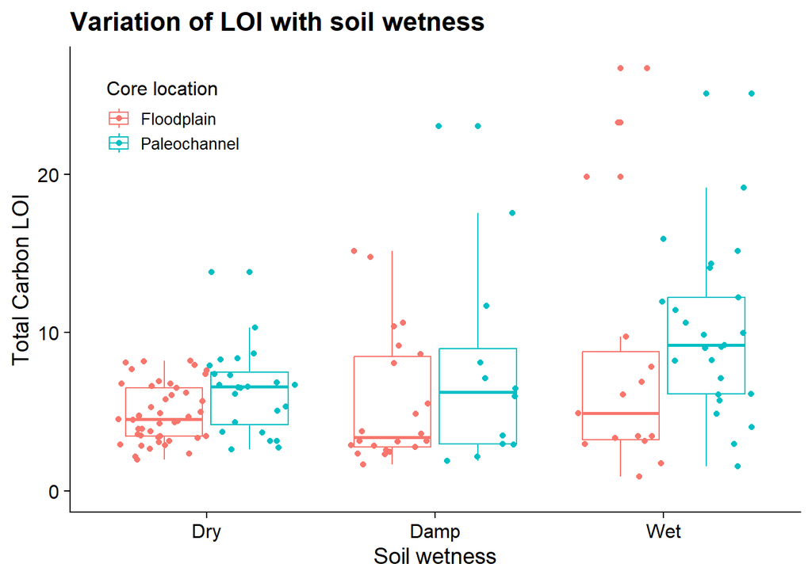

```r
soilloi_clean%>%
  ggplot(aes(x=factor(wetdrydamp,WetnessOrder), y=loi_calc, ymax =0.35, ymin = 0, colour = core_type)) +
  geom_boxplot()+
  geom_point(position = position_jitterdodge())+
  labs(x = "Soil wetness",
       y = "Total Carbon LOI",
       title = "Variation of LOI with soil wetness",
       colour = "Core location") +
  theme_cowplot() +
  theme(legend.position = c(0.05,0.85), legend.title = element_text(size =12), legend.text = element_text(size=10))
```

# Test if soil horizon data sets are significantly different for core location types

```r
FdpnDryLoi<-soilloi_clean %>%
  filter(wetdrydamp=="Dry") %>%
  filter(core_type=="Floodplain") %>%
  select(loi_calc) %>%
  pull()

FdpnDampLoi<-soilloi_clean %>%
  filter(wetdrydamp=="Damp") %>%
  filter(core_type=="Floodplain") %>%
  select(loi_calc) %>%
  pull()

FdpnWetLoi<-soilloi_clean %>%
  filter(wetdrydamp=="Wet") %>%
  filter(core_type=="Floodplain") %>%
  select(loi_calc) %>%
  pull()

PaleoDryLoi<-soilloi_clean %>%
  filter(wetdrydamp=="Dry") %>%
  filter(core_type=="Paleochannel") %>%
  select(loi_calc) %>%
  pull()

PaleoDampLoi<-soilloi_clean %>%
  filter(wetdrydamp=="Damp") %>%
  filter(core_type=="Paleochannel") %>%
  select(loi_calc) %>%
  pull()

PaleoWetLoi<-soilloi_clean %>%
  filter(wetdrydamp=="Wet") %>%
  filter(core_type=="Paleochannel") %>%
  select(loi_calc) %>%
  pull()

t.test(FdpnDryLoi,PaleoDryLoi)
```

```
##
##  Welch Two Sample t-test
##
## data:  FdpnDryLoi and PaleoDryLoi
## t = -2.391, df = 35.258, p-value = 0.02227
## alternative hypothesis: true difference in means is not equal to 0
## 95 percent confidence interval:
##  -2.6515591 -0.2167655
## sample estimates:
## mean of x mean of y
##  4.905449  6.339611
```

```r
t.test(FdpnDampLoi,PaleoDampLoi)
```

```
##
##  Welch Two Sample t-test
##
## data:  FdpnDampLoi and PaleoDampLoi
## t = -1.0236, df = 15.779, p-value = 0.3215
## alternative hypothesis: true difference in means is not equal to 0
## 95 percent confidence interval:
##  -6.595512  2.303547
## sample estimates:
## mean of x mean of y
##  5.641965  7.787947
```

```r
t.test(FdpnWetLoi,PaleoWetLoi)
```

```
##
##  Welch Two Sample t-test
##
## data:  FdpnWetLoi and PaleoWetLoi
## t = -0.76043, df = 21.065, p-value = 0.4554
## alternative hypothesis: true difference in means is not equal to 0
## 95 percent confidence interval:
##  -6.710158  3.116318
## sample estimates:
## mean of x mean of y
##   8.29582  10.09274
```

## Plot Floodplain1 data by core location

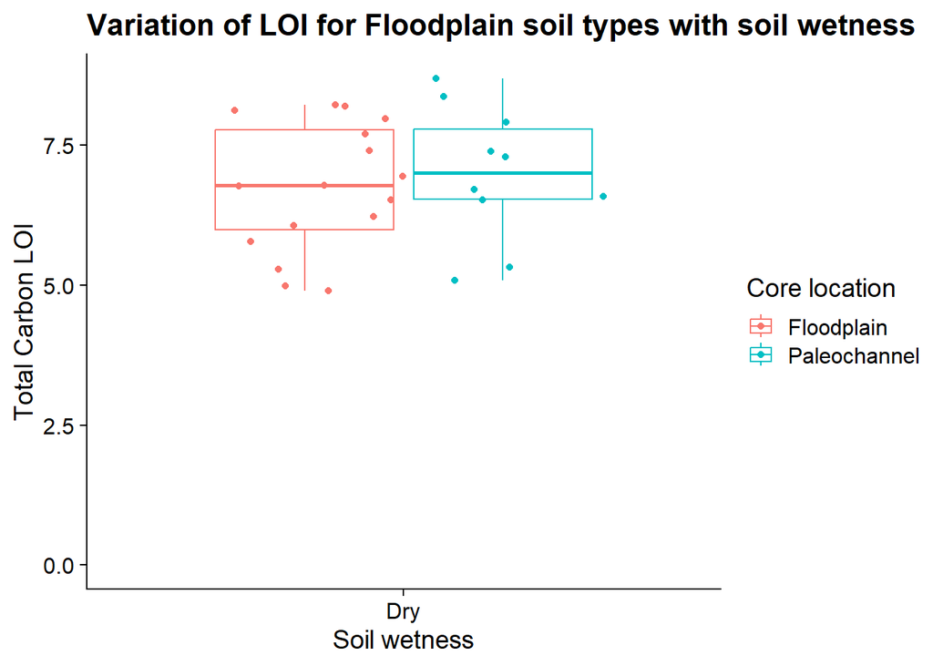

```r
soilloi_clean%>%
  filter(horizon_type=="Floodplain1")%>%
  ggplot(aes(x=factor(wetdrydamp,WetnessOrder), y=loi_calc, ymax =0.35, ymin = 0, colour = core_type)) +
  geom_boxplot()+
  geom_point(position = position_jitterdodge())+
  labs(x = "Soil wetness",
       y = "Total Carbon LOI",
       title = "Variation of LOI for Floodplain soil types with soil wetness",
       colour = "Core location") +
  theme_cowplot()
```

## Test if Floodplain1 soil horizon data sets are significantly different for core location types

```r
FdpnDryLoi<-soilloi_clean %>%
  filter(wetdrydamp=="Dry") %>%
  filter(horizon_type=="Floodplain1")%>%
  filter(core_type=="Floodplain") %>%
  select(loi_calc) %>%
  pull()

PaleoDryLoi<-soilloi_clean %>%
  filter(wetdrydamp=="Dry") %>%
  filter(horizon_type=="Floodplain1")%>%
  filter(core_type=="Paleochannel") %>%
  select(loi_calc) %>%
  pull()

t.test(FdpnDryLoi,PaleoDryLoi)
```

```
##
##  Welch Two Sample t-test
##
## data:  FdpnDryLoi and PaleoDryLoi
## t = -0.52399, df = 18.593, p-value = 0.6065
## alternative hypothesis: true difference in means is not equal to 0
## 95 percent confidence interval:
##  -1.2371294  0.7423083
## sample estimates:
## mean of x mean of y
##  6.742751  6.990162
```

## Plot Gley data by core location

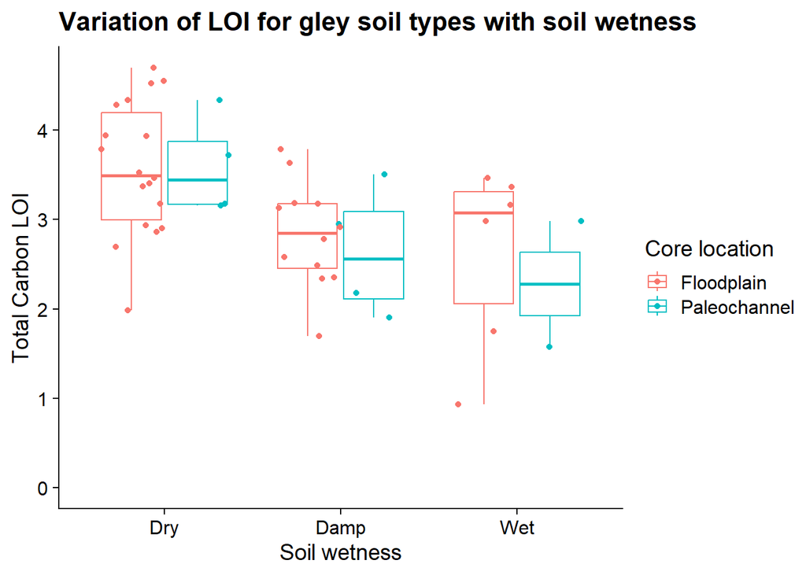

```r
soilloi_clean%>%
  filter(horizon_type=="Gley")%>%
  ggplot(aes(x=factor(wetdrydamp,WetnessOrder), y=loi_calc, ymax =0.35, ymin = 0, colour = core_type)) +
  geom_boxplot()+
  geom_point(position = position_jitterdodge())+
  labs(x = "Soil wetness",
       y = "Total Carbon LOI",
       title = "Variation of LOI for gley soil types with soil wetness",
       colour = "Core location") +
  theme_cowplot()
```

## Test if Gley soil horizon data sets are significantly different for core location types

```r
FdpnDryLoi<-soilloi_clean %>%
  filter(wetdrydamp=="Dry") %>%
  filter(horizon_type=="Gley")%>%
  filter(core_type=="Floodplain") %>%
  select(loi_calc) %>%
  pull()

FdpnDampLoi<-soilloi_clean %>%
  filter(wetdrydamp=="Damp") %>%
  filter(horizon_type=="Gley")%>%
  filter(core_type=="Floodplain") %>%
  select(loi_calc) %>%
  pull()

FdpnWetLoi<-soilloi_clean %>%
  filter(wetdrydamp=="Wet") %>%
  filter(horizon_type=="Gley")%>%
  filter(core_type=="Floodplain") %>%
  select(loi_calc) %>%
  pull()

PaleoDryLoi<-soilloi_clean %>%
  filter(wetdrydamp=="Dry") %>%
  filter(horizon_type=="Gley")%>%
  filter(core_type=="Paleochannel") %>%
  select(loi_calc) %>%
  pull()

PaleoDampLoi<-soilloi_clean %>%
  filter(wetdrydamp=="Damp") %>%
  filter(horizon_type=="Gley")%>%
  filter(core_type=="Paleochannel") %>%
  select(loi_calc) %>%
  pull()

PaleoWetLoi<-soilloi_clean %>%
  filter(wetdrydamp=="Wet") %>%
  filter(horizon_type=="Gley")%>%
  filter(core_type=="Paleochannel") %>%
  select(loi_calc) %>%
  pull()

t.test(FdpnDryLoi,PaleoDryLoi)
```

```
##
##  Welch Two Sample t-test
##
## data:  FdpnDryLoi and PaleoDryLoi
## t = -0.065509, df = 5.705, p-value = 0.95
## alternative hypothesis: true difference in means is not equal to 0
## 95 percent confidence interval:
##  -0.8354613  0.7924248
## sample estimates:
## mean of x mean of y
##  3.573314  3.594832
```

```r
t.test(FdpnDampLoi,PaleoDampLoi)
```

```
##
##  Welch Two Sample t-test
##
## data:  FdpnDampLoi and PaleoDampLoi
## t = 0.50809, df = 4.4018, p-value = 0.6358
## alternative hypothesis: true difference in means is not equal to 0
## 95 percent confidence interval:
##  -0.8728858  1.2814196
## sample estimates:
## mean of x mean of y
##  2.837237  2.632970
```

```r
t.test(FdpnWetLoi,PaleoWetLoi)
```

```
##
##  Welch Two Sample t-test
##
## data:  FdpnWetLoi and PaleoWetLoi
## t = 0.40093, df = 1.795, p-value = 0.7311
## alternative hypothesis: true difference in means is not equal to 0
## 95 percent confidence interval:
##  -3.613364  4.270562
## sample estimates:
## mean of x mean of y
##  2.607054  2.278455
```

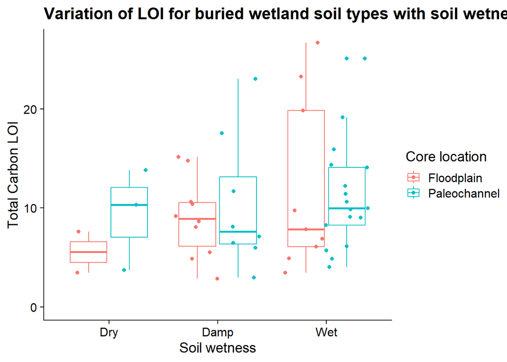

```r
soilloi_clean%>%
  filter(horizon_type=="BuriedWetland")%>%
  ggplot(aes(x=factor(wetdrydamp,WetnessOrder), y=loi_calc, ymax =0.35, ymin = 0, colour = core_type)) +
  geom_boxplot()+
  geom_point(position = position_jitterdodge())+
  labs(x = "Soil wetness",
       y = "Total Carbon LOI",
       title = "Variation of LOI for buried wetland soil types with soil wetness",
       colour = "Core location") +
  theme_cowplot()
```

## Test if Buried Wetland soil horizon data sets are significantly different for core location types

```r
FdpnDryLoi<-soilloi_clean %>%
  filter(wetdrydamp=="Dry") %>%
  filter(horizon_type=="BuriedWetland")%>%
  filter(core_type=="Floodplain") %>%
  select(loi_calc) %>%
  pull()

FdpnDampLoi<-soilloi_clean %>%
  filter(wetdrydamp=="Damp") %>%
  filter(horizon_type=="BuriedWetland")%>%
  filter(core_type=="Floodplain") %>%
  select(loi_calc) %>%
  pull()

FdpnWetLoi<-soilloi_clean %>%
  filter(wetdrydamp=="Wet") %>%
  filter(horizon_type=="BuriedWetland")%>%
  filter(core_type=="Floodplain") %>%
  select(loi_calc) %>%
  pull()

PaleoDryLoi<-soilloi_clean %>%
  filter(wetdrydamp=="Dry") %>%
  filter(horizon_type=="BuriedWetland")%>%
  filter(core_type=="Paleochannel") %>%
  select(loi_calc) %>%
  pull()

PaleoDampLoi<-soilloi_clean %>%
  filter(wetdrydamp=="Damp") %>%
  filter(horizon_type=="BuriedWetland")%>%
  filter(core_type=="Paleochannel") %>%
  select(loi_calc) %>%
  pull()

PaleoWetLoi<-soilloi_clean %>%
  filter(wetdrydamp=="Wet") %>%
  filter(horizon_type=="BuriedWetland")%>%
  filter(core_type=="Paleochannel") %>%
  select(loi_calc) %>%
  pull()

t.test(FdpnDryLoi,PaleoDryLoi)
```

```
##
##  Welch Two Sample t-test
##
## data:  FdpnDryLoi and PaleoDryLoi
## t = -1.0384, df = 2.9999, p-value = 0.3754
## alternative hypothesis: true difference in means is not equal to 0
## 95 percent confidence interval:
##  -15.228814   7.735872
## sample estimates:
## mean of x mean of y
##  5.547861  9.294332
```

```r
t.test(FdpnDampLoi,PaleoDampLoi)
```

```
##
##  Welch Two Sample t-test
##
## data:  FdpnDampLoi and PaleoDampLoi
## t = -0.5037, df = 10.814, p-value = 0.6246
## alternative hypothesis: true difference in means is not equal to 0
## 95 percent confidence interval:
##  -7.303340  4.587745
## sample estimates:
## mean of x mean of y
##  9.007638 10.365436
```

```r
t.test(FdpnWetLoi,PaleoWetLoi)
```

```
##
##  Welch Two Sample t-test
##
## data:  FdpnWetLoi and PaleoWetLoi
## t = 0.28664, df = 11.329, p-value = 0.7796
## alternative hypothesis: true difference in means is not equal to 0
## 95 percent confidence interval:
##  -6.085705  7.915580
## sample estimates:
## mean of x mean of y
##  12.08833  11.17339
```